# CCR7 expression defines distinct pTfh1 subsets involved in malaria immunity

Megan Soon and Damian Oyong

2025-03-03

```r
knitr::opts_chunk$set(echo = TRUE)
```

## Figure 1

Reading input Input can be found in zenodo https://zenodo.org/records/14847353 Raw data have been deposited in the NCBI data base under accession number GSE272939 https://www.ncbi.nlm.nih.gov/geo/query/acc.cgi?acc=GSE272939 and accession number GSE253661 https://www.ncbi.nlm.nih.gov/geo/query/acc.cgi?acc=GSE253661

#### Figure 1 B | UMAP of data following integration by donor, with 11 transcriptional subsets indicated

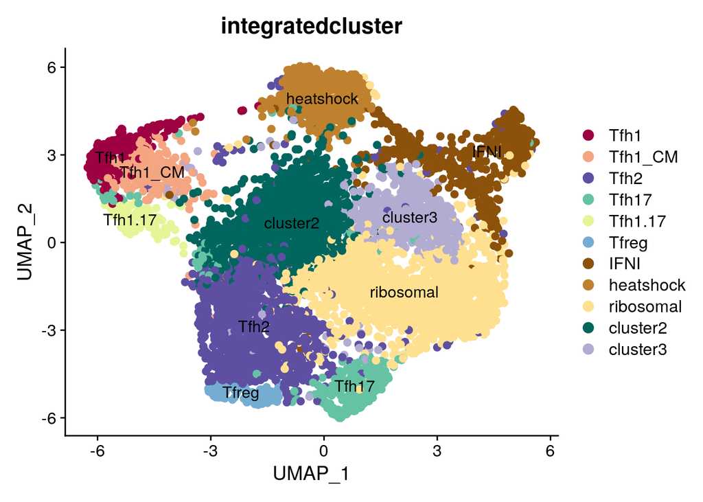

```r
DimPlot(Tfh.Map, label = TRUE, pt.size = 2, group.by = "integratedcluster",
        cols = c("#9e0142", "#f4a582", "#5e4fa2", "#66c2a5", "#e6f598",
                 "#74add1", "#8c510a", "#bf812d", "#fee090", "#01665e", "#b2abd2"))
```

#### Figure 1 C | UMAP of data depicting cell sorted identity

```r
DefaultAssay(Tfh.Map)
```

```
## [1] "RNA"
```

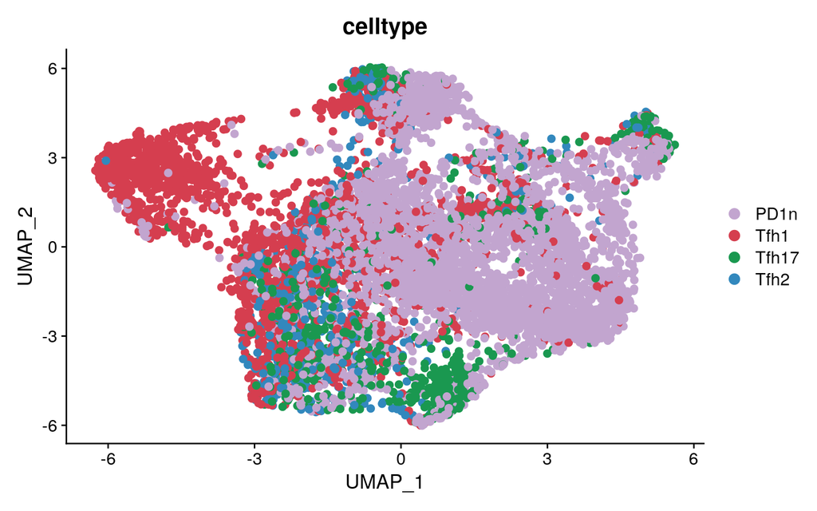

```r
DimPlot(Tfh.Map, label = FALSE, pt.size = 2, group.by = "celltype",
        cols = c("#c2a5cf","#d53e4f", "#1a9850", "#3288bd" ))
```

```r
DefaultAssay(Tfh.Map) <- "RNA"
Tfh.Map <- NormalizeData(Tfh.Map)

cluster.2m <- FindMarkers(Tfh.Map, ident.1 = "cluster2", group.by = "integratedcluster", min.pct = 0.1, verbose = FALSE, only.pos = FALSE)
cluster.3m <- FindMarkers(Tfh.Map, ident.1 = "cluster3", group.by = "integratedcluster", min.pct = 0.1, verbose = FALSE, only.pos = FALSE)
heatshock.m <- FindMarkers(Tfh.Map, ident.1 = "heatshock", group.by = "integratedcluster", min.pct = 0.1, verbose = FALSE, only.pos = FALSE)
IFNI.m <- FindMarkers(Tfh.Map, ident.1 = "IFNI", group.by = "integratedcluster", min.pct = 0.1, verbose = FALSE, only.pos = FALSE)
ribosomal.m <- FindMarkers(Tfh.Map, ident.1 = "ribosomal", group.by = "integratedcluster", min.pct = 0.1, verbose = FALSE, only.pos = FALSE)
Tfh1.m <- FindMarkers(Tfh.Map, ident.1 = "Tfh1", group.by = "integratedcluster", min.pct = 0.1, verbose = FALSE, only.pos = FALSE)
Tfh1_CM.m <- FindMarkers(Tfh.Map, ident.1 = "Tfh1_CM", group.by = "integratedcluster", min.pct = 0.1, verbose = FALSE, only.pos = FALSE)
Tfh1.17.m <- FindMarkers(Tfh.Map, ident.1 = "Tfh1.17", group.by = "integratedcluster", min.pct = 0.1, verbose = FALSE, only.pos = FALSE)
Tfh17.m <- FindMarkers(Tfh.Map, ident.1 = "Tfh17", group.by = "integratedcluster", min.pct = 0.1, verbose = FALSE, only.pos = FALSE)
Tfh2.m <- FindMarkers(Tfh.Map, ident.1 = "Tfh2", group.by = "integratedcluster", min.pct = 0.1, verbose = FALSE, only.pos = FALSE)
Tfreg.m <- FindMarkers(Tfh.Map, ident.1 = "Tfreg", group.by = "integratedcluster", min.pct = 0.1, verbose = FALSE, only.pos = FALSE)

DefaultAssay(Tfh.Map)
```

```
## [1] "RNA"
```

```r
##  add "neg" and "pos" to gene lists..
### can we also know how many are upregulated vs downregulated??
cluster.2m$dir_sig[cluster.2m$p_val_adj<0.01 & cluster.2m$avg_log2FC>0] <-"up"
cluster.2m$dir_sig[cluster.2m$p_val_adj<0.01 & cluster.2m$avg_log2FC<0] <-"down"

cluster.3m$dir_sig[cluster.3m$p_val_adj<0.01 & cluster.3m$avg_log2FC>0] <-"up"
cluster.3m$dir_sig[cluster.3m$p_val_adj<0.01 & cluster.3m$avg_log2FC<0] <-"down"

heatshock.m$dir_sig[heatshock.m$p_val_adj<0.01 & heatshock.m$avg_log2FC>0] <-"up"
heatshock.m$dir_sig[heatshock.m$p_val_adj<0.01 & heatshock.m$avg_log2FC<0] <-"down"

IFNI.m$dir_sig[IFNI.m$p_val_adj<0.01 & IFNI.m$avg_log2FC>0] <-"up"
IFNI.m$dir_sig[IFNI.m$p_val_adj<0.01 & IFNI.m$avg_log2FC<0] <-"down"

ribosomal.m$dir_sig[ribosomal.m$p_val_adj<0.01 & ribosomal.m$avg_log2FC>0] <-"up"
ribosomal.m$dir_sig[ribosomal.m$p_val_adj<0.01 & ribosomal.m$avg_log2FC<0] <-"down"

Tfh1.m$dir_sig[Tfh1.m$p_val_adj<0.01 & Tfh1.m$avg_log2FC>0] <-"up"
Tfh1.m$dir_sig[Tfh1.m$p_val_adj<0.01 & Tfh1.m$avg_log2FC<0] <-"down"

Tfh1_CM.m$dir_sig[Tfh1_CM.m$p_val_adj<0.01 & Tfh1_CM.m$avg_log2FC>0] <-"up"
Tfh1_CM.m$dir_sig[Tfh1_CM.m$p_val_adj<0.01 & Tfh1_CM.m$avg_log2FC<0] <-"down"

Tfh1.17.m$dir_sig[Tfh1.17.m$p_val_adj<0.01 & Tfh1.17.m$avg_log2FC>0] <-"up"
Tfh1.17.m$dir_sig[Tfh1.17.m$p_val_adj<0.01 & Tfh1.17.m$avg_log2FC<0] <-"down"

Tfh17.m$dir_sig[Tfh17.m$p_val_adj<0.01 & Tfh17.m$avg_log2FC>0] <-"up"
Tfh17.m$dir_sig[Tfh17.m$p_val_adj<0.01 & Tfh17.m$avg_log2FC<0] <-"down"

Tfh2.m$dir_sig[Tfh2.m$p_val_adj<0.01 & Tfh2.m$avg_log2FC>0] <-"up"
Tfh2.m$dir_sig[Tfh2.m$p_val_adj<0.01 & Tfh2.m$avg_log2FC<0] <-"down"

Tfreg.m$dir_sig[Tfreg.m$p_val_adj<0.01 & Tfreg.m$avg_log2FC>0] <-"up"
Tfreg.m$dir_sig[Tfreg.m$p_val_adj<0.01 & Tfreg.m$avg_log2FC<0] <-"down"

#### Get Tfh1 vs Tfh1.CM genes ####
Tfh1vsCM<- FindMarkers(Tfh.Map, ident.1 = "Tfh1", ident.2 = "Tfh1_CM", group.by = "integratedcluster", min.pct = 0.1, verbose = FALSE, only.pos = FALSE)
```

#### Figure 1 D | Relative gene expression of genes used to annotate transcriptional clusters.

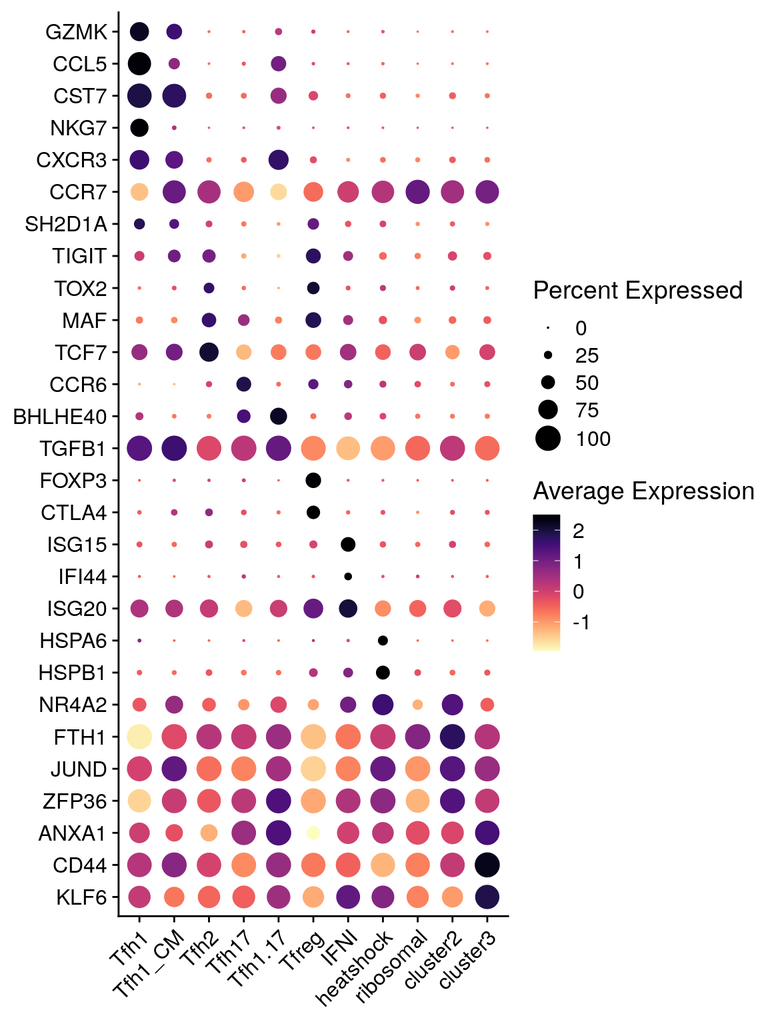

```r
dotplot.genes <- c("KLF6", "CD44", "ANXA1",
                   "ZFP36", "JUND", "FTH1", "NR4A2",
                   "HSPB1", "HSPA6",
                   "ISG20", "IFI44", "ISG15",
                   "CTLA4", "FOXP3",
                   "TGFB1", "BHLHE40", "CCR6",
                   "TCF7", "MAF", "TOX2",
                   "TIGIT", "SH2D1A", "CCR7", "CXCR3",
                   "NKG7", "CST7", "CCL5", "GZMK")

DotPlot_scCustom(Tfh.Map, features = dotplot.genes, colors_use = viridis_magma_dark_high,
                 group.by = "integratedcluster", flip_axes = T,
                 x_lab_rotate = TRUE)
```

#### Figure 1 E | Subset of genes differentially expressed between Tfh1_Cyto and Tfh1_CCR7 annotated transcriptional clusters

```r
# subset
Tfh1CM.sub <- subset(Tfh.Map, subset = integratedcluster %in% c("Tfh1", "Tfh1_CM"))

DefaultAssay(Tfh1CM.sub)
```

```
## [1] "RNA"
```

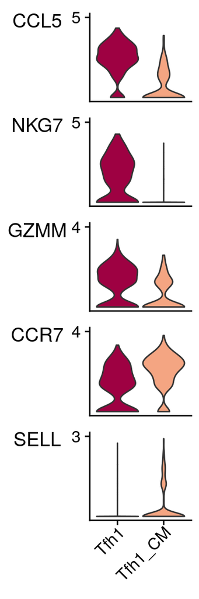

```r
Tfh1.CM_colors <- c("#9e0142", "#f4a582")

Tfh1.CM_list <- c("CCL5", "NKG7", "GZMM", "CCR7",  "SELL")

Stacked_VlnPlot(seurat_object = Tfh1CM.sub, features = Tfh1.CM_list, x_lab_rotate = TRUE,
                colors_use = Tfh1.CM_colors, group.by = "integratedcluster")
```

#### Figure 1 F | Relationship between cell sorted identity and transcriptional cluster identity in the data set

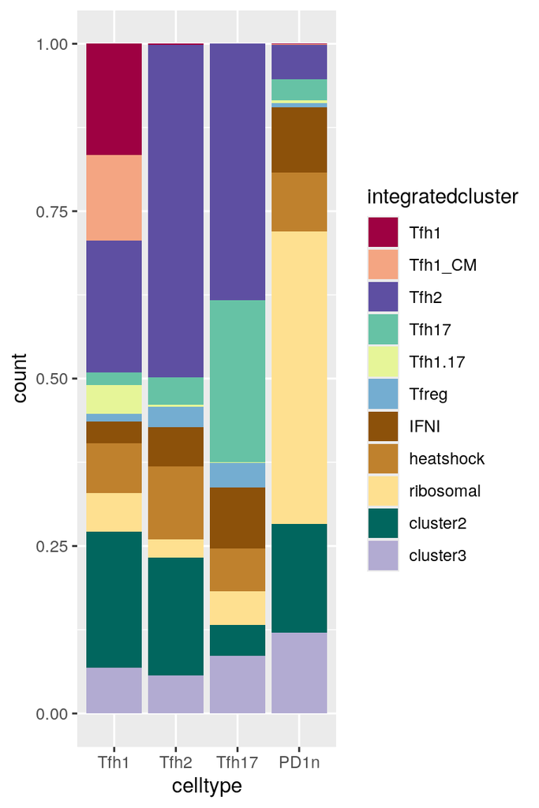

```r
Tfh.Map@meta.data$celltype = factor(Tfh.Map@meta.data$celltype, levels=c("Tfh1","Tfh2", "Tfh17", "PD1n" ))

ggplot(data = as.data.frame(Tfh.Map@meta.data), aes(x = celltype, fill = integratedcluster)) +
  geom_bar(position = "fill") +
  scale_fill_manual(values = c("#9e0142", "#f4a582", "#5e4fa2", "#66c2a5", "#e6f598",
                               "#74add1", "#8c510a", "#bf812d", "#fee090", "#01665e", "#b2abd2"))
```

##### TCR analysis Figure 1

Input data, can be downloaded from the NCBI data base under accession number GSE272939 https://www.ncbi.nlm.nih.gov/geo/query/acc.cgi?acc=GSE272939

```r
setwd(dirname(rstudioapi::getActiveDocumentContext()$path)) # This only works if you are using RStudio

file.names <- list.files(pattern = 'filtered_contig_annotations.csv', recursive = TRUE)
names <- list.files(path='VDJ_Mode')

file_seq <- 1:length(file.names)

if(any(grepl("*.csv", file.names))==TRUE){
  tfh_tcr <- file.names %>%
    lapply(., function(i){
      fread(input = i)
    }) %>%
    setNames(names)
}


tfh_tcr <- combineTCR(tfh_tcr,
                      samples = names,
                      removeNA = TRUE,
                      removeMulti = TRUE,
                      filterMulti = TRUE)


## Now we need to edit the barcode, delete everything before "v3_"

tfh_tcr <- tfh_tcr %>%
  purrr::map(~.x %>% mutate(barcode = gsub(".*v3_","",barcode)))


tfh_tcr <- tfh_tcr[c("Tfh1_vdjMode_BoyleLab_vdj_ref_v3","Tfh2_vdjMode_BoyleLab_vdj_ref_v3",
                     "Tfh17_vdjMode_BoyleLab_vdj_ref_v3","PD1Neg_vdjMode_BoyleLab_vdj_ref_v3")]

tfh_tcr <- tfh_tcr %>%
  purrr::map2(., file_seq, ~mutate(.x, barcode = sub(1, .y, barcode)))

#write.csv(tfh_tcr, "tfh_tcr_db_30325.csv")
```

```r
#Combining expression and VDJ output
tfh_rep <- combineExpression(tfh_tcr, Tfh.Map,
                             cloneCall="aa",
                             proportion = FALSE,
                             cloneSize=c(Single=1, Small=5, Medium=20, Large=100, Hyperexpanded=500))

tfh_rep@meta.data$integratedcluster <-  factor(tfh_rep@meta.data$integratedcluster,
                                               levels = c("Tfh1", "Tfh1_CM", "Tfh2", "Tfh17", "Tfh1.17", "Tfreg", "IFNI",
                                                          "heatshock", "ribosomal", "cluster2", "cluster3"))

cluster_col <- c("Tfh1" = "#9e0142", "Tfh1_CM" = "#f4a582",
                 "Tfh2" =  "#5e4fa2", "Tfh17" = "#66c2a5",
                 "Tfh1.17" = "#e6f598", "Tfreg" = "#74add1",
                 "IFNI" = "#8c510a", "heatshock" = "#bf812d",
                 "ribosomal"= "#fee090","cluster2" = "#01665e", "cluster3" = "#b2abd2")

cluster_orders <- c("Tfh1", "Tfh1_CM", "Tfh2", "Tfh17", "Tfh1.17", "Tfreg", "IFNI", "heatshock", "ribosomal", "cluster2", "cluster3")
```

```r
cell.prop <- tfh_rep@meta.data %>%
  mutate(TCR = case_when(is.na(CTaa) == TRUE ~ "No",
                         TRUE ~ "Yes"))

cell.prop <- cell.prop %>%
  group_by(cloneSize) %>%
  summarise(n = n())
```

```
## `use_raster` is automatically set to TRUE for a matrix with more than
## 2000 columns You can control `use_raster` argument by explicitly
## setting TRUE/FALSE to it.
##
## Set `ht_opt$message = FALSE` to turn off this message.
```

```
## 'magick' package is suggested to install to give better rasterization.
##
## Set `ht_opt$message = FALSE` to turn off this message.
```

[figure not shown]

```r
fidel <- tfh_rep@meta.data %>%
  select(CTaa, integratedcluster) %>%
  tibble::remove_rownames() %>%
  group_by(CTaa, integratedcluster) %>%
  summarise(n = n()) %>%
  ungroup() %>%
  group_by(CTaa) %>%
  mutate(total = sum(n)) %>%
  ungroup() %>%
  mutate(prop = n/total) %>%
  select(-c(n, total)) %>%
  pivot_wider(names_from = CTaa, values_from = prop) %>%
  arrange(., integratedcluster) %>%
  column_to_rownames(., var = "integratedcluster") %>%
  mutate_all(~replace(., is.na(.), 0)) %>%
  arrange()

count_per_clone <- tfh_rep@meta.data %>%
  select(CTaa) %>%
  tibble::remove_rownames() %>%
  group_by(CTaa) %>%
  summarise(n = n())

cluster_count <- tfh_rep@meta.data %>%
  select(CTaa, integratedcluster) %>%
  remove_rownames() %>%
  group_by(integratedcluster) %>%
  summarise(n = n()) %>%
  mutate(prop = n/sum(n)*100) %>%
  column_to_rownames(., var = "integratedcluster")

fidel <- as.matrix(fidel)

Heatmap((fidel),
        name = "Clonal Proportion",
        cluster_columns = T, column_dend_side = "bottom", clustering_method_columns = "ward.D2",
        cluster_rows = F,
        show_column_names = F,
        top_annotation = HeatmapAnnotation(Count = anno_barplot(
          count_per_clone$n, axis_param = list(at = c(2, 5, 12))),
          annotation_name_rot = 90),
        width = ncol(fidel)*unit(0.05, "in"),
        height = nrow(fidel)*unit(0.6, "in"),
        col = colorRampPalette(RColorBrewer::brewer.pal(9, "Greens"))(100))
```

```r
        # Use continuous scale with 100 shades
dev.set()
```

## Figure 4

##### Reading data for Figure 4

```r
Tfh.IBSM <- readRDS("/working_groups/boylelab/shared/ZulyPava/Tfh_diversity_finalcode/input/TfhIBSM_mappedtofullREF_reannotated_230523_v2.rds")

DefaultAssay(Tfh.IBSM) <- "integrated"
# remove cluster 13, 30, 24, 29, 23, 17 bc they are low quality clusters
Tfh.IBSM.2 <- subset(Tfh.IBSM, subset = integrated_snn_res.2.2 %in% c(0,1,2,3,4,5,6,7,8,9,10,11,12,14,15,16,18,19,20,21,22,25,26,27,28))


###### scType label.....
# load gene set preparation function
source("https://raw.githubusercontent.com/IanevskiAleksandr/sc-type/master/R/gene_sets_prepare.R")
# load cell type annotation function
source("https://raw.githubusercontent.com/IanevskiAleksandr/sc-type/master/R/sctype_score_.R")

db_ = "/working_groups/boylelab/shared/ZulyPava/Tfh_diversity_finalcode/input/TfhMap_ClusterMarkers_DB_Reannotated_postnorm_190724.xlsx";
tissue = "Immune system"

# prepare gene sets
gs_list = gene_sets_prepare(db_, tissue)

# get cell-type by cell matrix
es.max = sctype_score(scRNAseqData = Tfh.IBSM.2[["integrated"]]@scale.data, scaled = TRUE,
                      gs = gs_list$gs_positive, gs2 = gs_list$gs_negative)

#write.csv(es.max, "TfhIBSM_scType_esmax_scoringpercell_310524.csv")
# merge by cluster
cL_resutls = do.call("rbind", lapply(unique(Tfh.IBSM.2@meta.data$integrated_snn_res.2.2), function(cl){
  es.max.cl = sort(rowSums(es.max[ ,rownames(Tfh.IBSM.2@meta.data[Tfh.IBSM.2@meta.data$integrated_snn_res.2.2==cl, ])]), decreasing = !0)
  head(data.frame(cluster = cl, type = names(es.max.cl), scores = es.max.cl, ncells = sum(Tfh.IBSM.2@meta.data$integrated_snn_res.2.2==cl)), 10)
}))

sctype_scores = cL_resutls %>% group_by(cluster) %>% top_n(n = 1, wt = scores)

write.csv(cL_resutls, "TfhIBSM_scType_clresults_scoringpercluster_310524.csv")
write.csv(sctype_scores, "TfhIBSM_scType_sctypesscore_scoringpercluster_summary_310524.csv")

# set low-confident (low ScType score) clusters to "unknown"
sctype_scores$type[as.numeric(as.character(sctype_scores$scores)) < sctype_scores$ncells/4] = "Unknown"
#print(sctype_scores[,1:3])

Tfh.IBSM.2@meta.data$customclassif = ""
for(j in unique(sctype_scores$cluster)){
  cl_type = sctype_scores[sctype_scores$cluster==j,];
  Tfh.IBSM.2@meta.data$customclassif[Tfh.IBSM.2@meta.data$integrated_snn_res.2.2 == j] = as.character(cl_type$type[1])
}

sctype_scores$type <- factor(sctype_scores$type, levels = c("Tfh1", "Tfh1_CM", "Tfh2", "Tfh17",
                                                            "IFNI", "heatshock", "ribo", "cluster2", "cluster3"))
cL_df <- cL_resutls
# cL_df <- read.csv("TfhIBSM_scType_cL_results_postnorm_200724.csv")
#cL_df <- cL_df[, -c(1,5)]

Tfh.IBSM.2@meta.data$customclassif <- factor(Tfh.IBSM.2@meta.data$customclassif, levels = c("Tfh1", "Tfh1_CM", "Tfh2", "Tfh17","IFNI", "heatshock", "ribo", "cluster2", "cluster3"))

Idents(object = Tfh.IBSM.2) <- "customclassif"

Tfh.IBSM.2@meta.data$seurat_clusters <- Tfh.IBSM.2@meta.data$customclassif

metadata <- as.data.frame(Tfh.IBSM.2@meta.data)
metadata$alternative_clusters <- metadata$seurat_clusters

# Assuming your metadata is in a data frame called metadata
metadata <- metadata %>%
  mutate(alternative_clusters = as.character(alternative_clusters)) %>%
  mutate(alternative_clusters = ifelse(alternative_clusters == "Tfh2" & integrated_snn_res.2.2 == 14, "Tfh1_CM", alternative_clusters))


metadata <- metadata %>%
  mutate(alternative_clusters = as.character(alternative_clusters)) %>%
  mutate(alternative_clusters = ifelse(alternative_clusters == "Tfh17" & integrated_snn_res.2.2 == 19, "cluster2", alternative_clusters))

Tfh.IBSM.2@meta.data <- metadata
#saveRDS(Tfh.IBSM.2, "Tfh.IBSM.2_REANNOTATION_POSTNORM_V2_200724.rds")
```

```r
TfhIBSM <- readRDS("/working_groups/boylelab/shared/ZulyPava/Tfh_diversity_finalcode/input/Tfh.IBSM.2_REANNOTATION_POSTNORM_V2_200724.rds")

DefaultAssay(TfhIBSM)
```

```
## [1] "RNA"
```

#### Figure 4 A | pTfh cells (CXCR5+PD1+nnCD4 T cells) were isolated from individuals (n=4) during controlled human malaria infection (CHMI) at day 0, 8, 16 and 36. scType label transfer was used to identify Tfh transcriptional subsets using the healthy Tfh cell data set as a reference

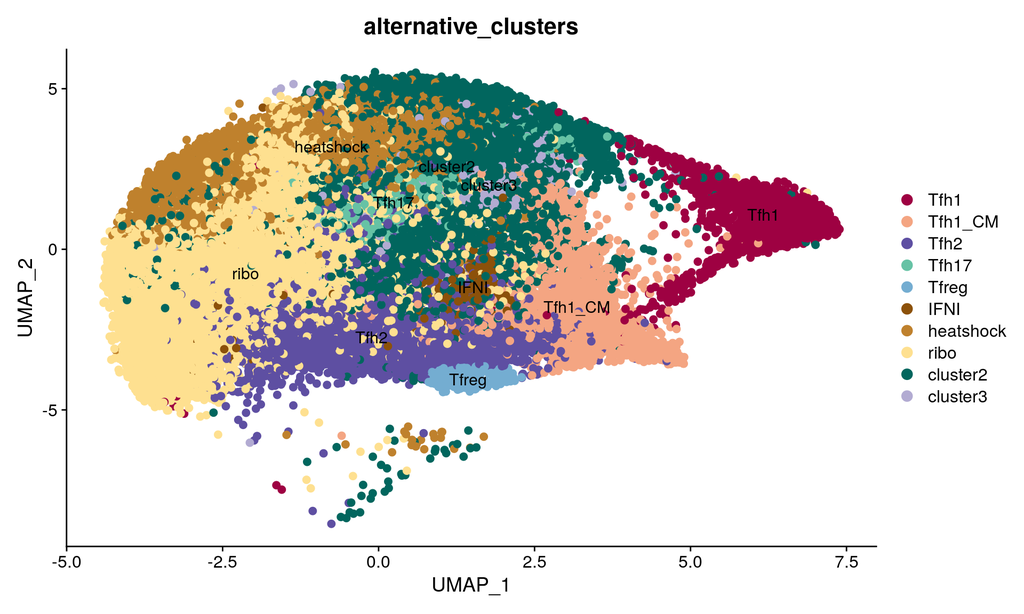

```r
Tfh_colors_list <- c("#9e0142", "#f4a582", "#5e4fa2", "#66c2a5", "#74add1",
                     "#8c510a", "#bf812d", "#fee090", "#01665e", "#b2abd2")

TfhIBSM@meta.data$alternative_clusters <- factor(TfhIBSM@meta.data$alternative_clusters,
                                               levels = c("Tfh1", "Tfh1_CM", "Tfh2", "Tfh17",
                                                          "Tfreg", "IFNI", "heatshock", "ribo",
                                                          "cluster2", "cluster3"))

DimPlot(TfhIBSM, group.by = "alternative_clusters", cols = Tfh_colors_list, pt.size = 2, label = T)
```

##### Calculating significant marker genes

```r
# to check if lognorm has been performed... or alternatively just run each counts/data separately, logorm will be non-integers ie 1.xxx
TfhIBSM[['RNA']]@counts@x == TfhIBSM[['RNA']]@data@x

FeaturePlot(TfhIBSM, c("CXCR3")) # also confirmed lognorm has been applied..

FeaturePlot(TfhIBSM, c("CXCR4"), pt.size = 0.5, order = T) # also confirmed lognorm has been applied..

############# let's find markers for each cluster
cluster2.markers <- FindMarkers(TfhIBSM, ident.1 = "cluster2", group.by = "alternative_clusters", min.pct = 0.1, only.pos = FALSE)
cluster3.markers <- FindMarkers(TfhIBSM, ident.1 = "cluster3", group.by = "alternative_clusters", min.pct = 0.1, only.pos = FALSE)
heatshock.markers <- FindMarkers(TfhIBSM, ident.1 = "heatshock", group.by = "alternative_clusters", min.pct = 0.1, only.pos = FALSE)
IFNI.markers <- FindMarkers(TfhIBSM, ident.1 = "IFNI", group.by = "alternative_clusters", min.pct = 0.1, only.pos = FALSE)
ribo.markers <- FindMarkers(TfhIBSM, ident.1 = "ribo", group.by = "alternative_clusters", min.pct = 0.1, only.pos = FALSE)
Tfh1.markers <- FindMarkers(TfhIBSM, ident.1 = "Tfh1", group.by = "alternative_clusters", min.pct = 0.1, only.pos = FALSE)
Tfh17.markers <- FindMarkers(TfhIBSM, ident.1 = "Tfh17", group.by = "alternative_clusters", min.pct = 0.1, only.pos = FALSE)
Tfh2.markers <- FindMarkers(TfhIBSM, ident.1 = "Tfh2", group.by = "alternative_clusters", min.pct = 0.1, only.pos = FALSE)
Tfh1_CM.markers <- FindMarkers(TfhIBSM, ident.1 = "Tfh1_CM", group.by = "alternative_clusters", min.pct = 0.1, only.pos = FALSE)
Tfreg.markers <- FindMarkers(TfhIBSM, ident.1 = "Tfreg", group.by = "alternative_clusters", min.pct = 0.1, only.pos = FALSE)

##  add "neg" and "pos" to gene lists..
### can we also know how many are upregulated vs downregulated??
cluster2.markers$dir_sig[cluster2.markers$p_val_adj<0.01 & cluster2.markers$avg_log2FC>0] <-"up"
cluster2.markers$dir_sig[cluster2.markers$p_val_adj<0.01 & cluster2.markers$avg_log2FC<0] <-"down"

cluster3.markers$dir_sig[cluster3.markers$p_val_adj<0.01 & cluster3.markers$avg_log2FC>0] <-"up"
cluster3.markers$dir_sig[cluster3.markers$p_val_adj<0.01 & cluster3.markers$avg_log2FC<0] <-"down"

heatshock.markers$dir_sig[heatshock.markers$p_val_adj<0.01 & heatshock.markers$avg_log2FC>0] <-"up"
heatshock.markers$dir_sig[heatshock.markers$p_val_adj<0.01 & heatshock.markers$avg_log2FC<0] <-"down"

IFNI.markers$dir_sig[IFNI.markers$p_val_adj<0.01 & IFNI.markers$avg_log2FC>0] <-"up"
IFNI.markers$dir_sig[IFNI.markers$p_val_adj<0.01 & IFNI.markers$avg_log2FC<0] <-"down"

ribo.markers$dir_sig[ribo.markers$p_val_adj<0.01 & ribo.markers$avg_log2FC>0] <-"up"
ribo.markers$dir_sig[ribo.markers$p_val_adj<0.01 & ribo.markers$avg_log2FC<0] <-"down"

Tfh1.markers$dir_sig[Tfh1.markers$p_val_adj<0.01 & Tfh1.markers$avg_log2FC>0] <-"up"
Tfh1.markers$dir_sig[Tfh1.markers$p_val_adj<0.01 & Tfh1.markers$avg_log2FC<0] <-"down"

Tfh1_CM.markers$dir_sig[Tfh1_CM.markers$p_val_adj<0.01 & Tfh1_CM.markers$avg_log2FC>0] <-"up"
Tfh1_CM.markers$dir_sig[Tfh1_CM.markers$p_val_adj<0.01 & Tfh1_CM.markers$avg_log2FC<0] <-"down"

Tfh17.markers$dir_sig[Tfh17.markers$p_val_adj<0.01 & Tfh17.markers$avg_log2FC>0] <-"up"
Tfh17.markers$dir_sig[Tfh17.markers$p_val_adj<0.01 & Tfh17.markers$avg_log2FC<0] <-"down"

Tfh2.markers$dir_sig[Tfh2.markers$p_val_adj<0.01 & Tfh2.markers$avg_log2FC>0] <-"up"
Tfh2.markers$dir_sig[Tfh2.markers$p_val_adj<0.01 & Tfh2.markers$avg_log2FC<0] <-"down"

Tfreg.markers$dir_sig[Tfreg.markers$p_val_adj<0.01 & Tfreg.markers$avg_log2FC>0] <-"up"
Tfreg.markers$dir_sig[Tfreg.markers$p_val_adj<0.01 & Tfreg.markers$avg_log2FC<0] <-"down"
```

#### Figure 4 B | Relative expression of marker genes used to annotate reference data set in each subset in CHMI data

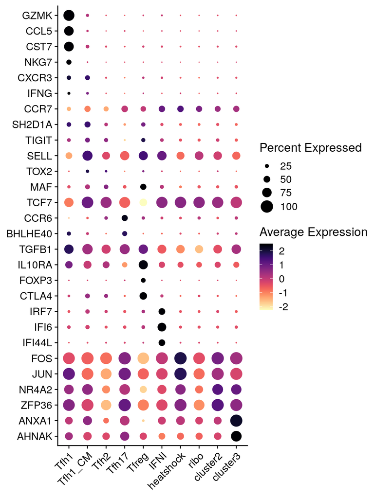

```r
dotplot.genes <- c("AHNAK", "ANXA1",
                   "ZFP36", "NR4A2",
                   "JUN", "FOS",
                   "IFI44L", "IFI6", "IRF7",
                   "CTLA4", "FOXP3", "IL10RA",
                   "TGFB1", "BHLHE40", "CCR6",
                   "TCF7", "MAF", "TOX2",
                   "SELL","TIGIT", "SH2D1A", "CCR7", "IFNG", "CXCR3",
                   "NKG7", "CST7", "CCL5", "GZMK")

DotPlot_scCustom(TfhIBSM, features = dotplot.genes, colors_use = viridis_magma_dark_high,
                 group.by = "alternative_clusters", flip_axes = T,
                x_lab_rotate = TRUE)
```

#### Figure 4 C | Relative proportion of each pTfh transcriptional cluster during CHMI

```r
metadata <- as.data.frame(TfhIBSM@meta.data)

try <- metadata[, c("seurat_clusters", "day", "donor_id", "alternative_clusters")]

try.4 <- try %>%
  group_by(alternative_clusters, donor_id, day) %>%   # grouping
  summarise(n = n()) %>%
  mutate(freq = n / sum(n))

try.4$donor_id <- factor(try.4$donor_id, levels = c("donor0", "donor1", "donor2", "donor3"))

try.4$day <- factor(try.4$day, levels = c("day0", "day8", "day16", "day36"))

try.4$alternative_clusters <- factor(try.4$alternative_clusters,
                                levels = c("Tfh1", "Tfh1_CM", "Tfh2", "Tfh17","Tfh1.17",
                                           "Tfreg", "IFNI", "heatshock", "ribo",
                                           "cluster2", "cluster3"))
##Only clusters showing
clusts = c("Tfh1", "Tfh1_CM", "Tfh2", "Tfh17")
```

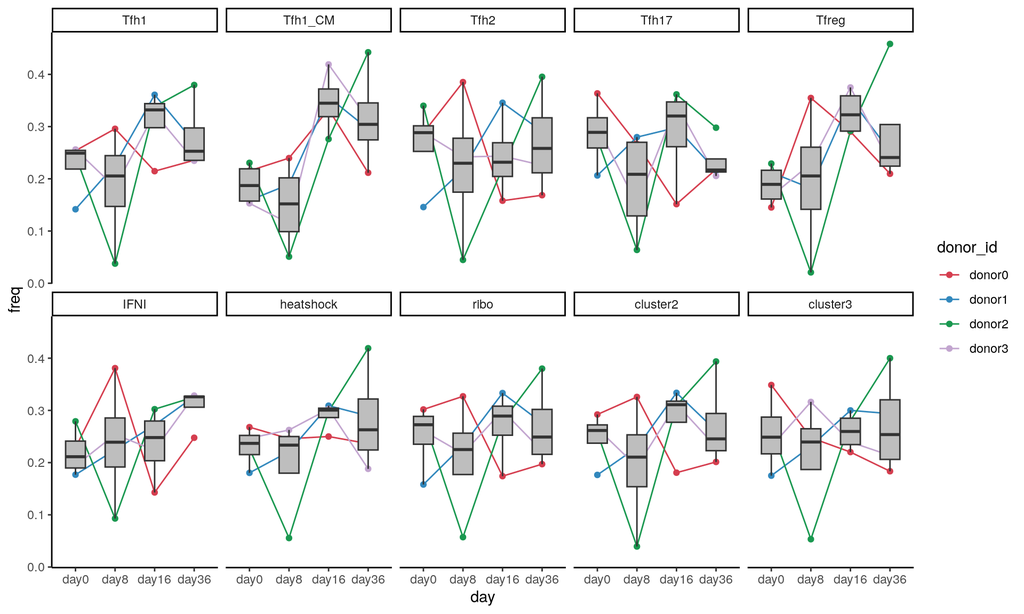

```r
ggplot(data = try.4, aes(x=day, y=freq)) +
  geom_line(aes(group = donor_id, colour = donor_id)) +
  geom_point(aes(group = donor_id, colour = donor_id)) +
  geom_boxplot(data = try.4, fill = "grey", width = 0.5, outlier.shape = NA) +
  facet_wrap(~alternative_clusters, ncol = 5) +
  theme_classic() +
  scale_colour_manual(values = c("#d53e4f", "#3288bd", "#1a9850", "#c2a5cf"))
```

##### TCR analysis Figure 4.

```r
setwd(dirname(rstudioapi::getActiveDocumentContext()$path)) # This only works if you are using RStudio

file.names <- list.files(pattern = 'filtered_contig_annotations.csv', recursive = TRUE)
names <- list.files(path='VDJ')

file_seq <- 1:length(file.names)

if(any(grepl("*.csv", file.names))==TRUE){
  ibsm_tcr <- file.names %>%
    lapply(., function(i){
      fread(input = i)
    }) %>%
    setNames(names)
}

ibsm_tcr <- ibsm_tcr[mixedsort(names(ibsm_tcr))]

ibsm_tcr <- ibsm_tcr %>%
  map2(., file_seq, ~mutate(.x, barcode = sub(1, .y, barcode)))

names <- names(ibsm_tcr)

ibsm_tcr <- combineTCR(ibsm_tcr,
                       samples = names,
                       removeNA = TRUE,
                       removeMulti = TRUE,
                       filterMulti = TRUE)

## Now we need to edit the barcode, delete everything before "v3_"

ibsm_tcr <- ibsm_tcr %>%
  map(~.x %>% mutate(barcode = gsub(".*VDJ_","",barcode)))

#write.csv(ibsm_tcr, "ibsm40_tcr_db_30325.csv")
```

##### Import Seurat

```r
##reading seurat object
ibsm <- readRDS("/working_groups/boylelab/shared/ZulyPava/Tfh_diversity_finalcode/input/Tfh.IBSM.2_REANNOTATION_POSTNORM_V2_200724.rds")
```

##### Combine VDJ and Seurat

```r
ibsm_rep <- combineExpression(ibsm_tcr, ibsm,
                              cloneCall="aa",
                              proportion = FALSE,
                              cloneSize=c(Single=1, Small=5, Medium=20, Large=100, Hyperexpanded=500))

ibsm_rep@meta.data$seurat_clusters <-  factor(ibsm_rep@meta.data$seurat_clusters,
                                              levels = c("Tfh1", "Tfh1_CM", "Tfh2", "Tfh17", "Tfh1.17", "Tfreg", "IFNI",
                                                         "heatshock", "ribo", "cluster2", "cluster3"))

ibsm_rep@meta.data$alternative_clusters <-  factor(ibsm_rep@meta.data$alternative_clusters,
                                              levels = c("Tfh1", "Tfh1_CM", "Tfh2", "Tfh17", "Tfh1.17", "Tfreg", "IFNI",
                                                         "heatshock", "ribo", "cluster2", "cluster3"))
```

##### How many cells:TCR

```r
cell.prop <- ibsm_rep@meta.data %>%
  mutate(TCR = case_when(is.na(CTaa) == TRUE ~ "No",
                         TRUE ~ "Yes"))

## Clonal frequency to send to Megan

clone_freq <- ibsm_rep@meta.data %>%
  select(CTaa, clonalFrequency) %>%
  mutate(clonalFrequency = case_when(is.na(clonalFrequency) ~ sum(is.na(CTaa)),
                                     TRUE ~ clonalFrequency))
```

##### Getting data for Figure 4D

```r
##Setting up right colors
cluster_col <- c("Tfh1" = "#9e0142", "Tfh1_CM" = "#f4a582", "Tfh2" = "#5e4fa2",
                 "Tfh17" = "#66c2a5", "Tfh1.17" = "#e6f598", "Tfreg" = "#74add1",
                 "IFNI" = "#8c510a", "heatshock" = "#bf812d", "ribosomal" = "#fee090",
                 "cluster2" = "#01665e", "cluster3" = "#b2abd2")

cluster_orders <- c("Tfh1", "Tfh1_CM", "Tfh2", "Tfh17", "Tfh1.17", "Tfreg", "IFNI", "heatshock", "ribo", "cluster2", "cluster3")

donor_col <- c("donor0"="#d53e4f", "donor1"="#3288bd", "donor2"="#1a9850", "donor3" = "#c2a5cf")

##Determine clone order
clone_order <- rev(mixedsort(unique(filter(ibsm_rep@meta.data, !is.na(cloneSize))$cloneSize)))


ibsm_rep@meta.data <- ibsm_rep@meta.data %>%
  mutate(cloneN = case_when(clonalFrequency == 1 ~ "1",
                               clonalFrequency == 2 ~ "2",
                               clonalFrequency == 3 ~ "3",
                               clonalFrequency == 4 ~ "4",
                               clonalFrequency > 5 ~ ">5")) %>%
  mutate(cloneN = factor(cloneN, levels = c('1','2','3','4','>5')))


ibsm_rep@meta.data <- ibsm_rep@meta.data %>%
  mutate(cloneN2 = case_when(clonalFrequency == 1 ~ "Clone # (N=1)",
                               clonalFrequency > 1 ~ "Clone # (N>1)")) %>%
  mutate(cloneN2 = factor(cloneN2, levels = c('Clone # (N=1)','Clone # (N>1)')),
         day = factor(day, levels = c("day0", "day8", "day16", "day36")))

RColorBrewer::brewer.pal(name = "Spectral", n = 11)
```

```
##  [1] "#9E0142" "#D53E4F" "#F46D43" "#FDAE61" "#FEE08B" "#FFFFBF" "#E6F598"
##  [8] "#ABDDA4" "#66C2A5" "#3288BD" "#5E4FA2"
```

```r
count_data <- ibsm_rep@meta.data %>%
  filter(!is.na(cloneN)) %>%
  group_by(day, donor_day, donor_id) %>%
  count(cloneN2) %>%
  mutate(day = factor(day, levels = c("day0","day8","day16","day36")))

p <- count_data %>%
  group_by(cloneN2) %>%
  wilcox_test(n ~ day, paired = F) %>%
  add_y_position()
```

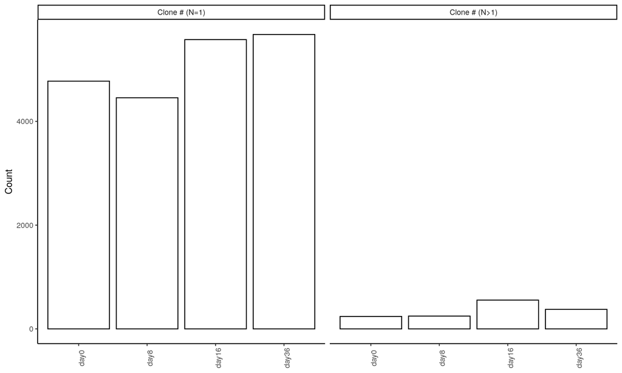

```r
ggplot(count_data, aes(x = day, y = n)) +
  stat_summary(fun=sum, geom="bar", fill = "white", color = "black")+
  theme_classic() +
  # scale_fill_manual(values = c("grey","#ABDDA4", "#66C2A5", "#3288BD", "#5E4FA2")) +
  labs(y = "Count") +
  theme(axis.title.x = element_blank(), axis.text.x = element_text(angle = 90)) +
  facet_wrap(~cloneN2) +
  stat_pvalue_manual(p, label = "p", hide.ns = "p")
```

#### Figure 4 E | Clone family size count over time in each subset - Clonal expansion was detected in Tfh1_cyto, Tfh1_CCR7 and Tfh2 clusters at day 16

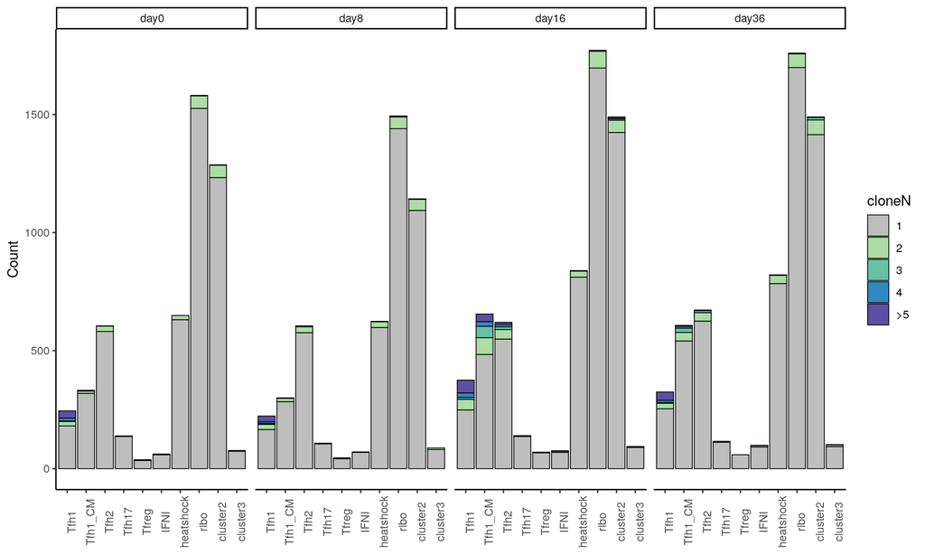

```r
ggplot(filter(ibsm_rep@meta.data, !is.na(cloneN)),
       aes(x = alternative_clusters, fill = cloneN))+
  geom_bar(colour = "black", position = position_stack(reverse = TRUE), linewidth = 0.3)+
  # geom_text(stat='count', aes(label= ..count..), vjust=-1)+
  # scale_x_discrete(limits = clone_order)+
  theme_classic()+
  # scale_fill_brewer(palette = "GnBu", direction = 1)+
  scale_fill_manual(values = c("grey","#ABDDA4", "#66C2A5", "#3288BD", "#5E4FA2"))+
  labs(y = "Count")+
  theme(axis.title.x = element_blank(),
        axis.text.x = element_text(angle=90))+
  facet_wrap(~day, nrow = 1)
```

##### Calculating Simpsons diversity Index in each donor across time

Create a diversity plot for donor_day (per donor and all donor overtime)

NOTE: scRepertoire exportTable output generating WRONG output by rounding off data to whole number. E.g. diversity 0.99 or 0.97 will be rounded off to 1 in exportTable. This is INCORRECT. The plots however, generate the correct diversity index values.

Use this guide from 10x https://kb.10xgenomics.com/hc/en-us/articles/13303807883405-How-to-calculate-paired-clonotype-diversity

```r
## We need to downsample first
count <- ibsm_rep@meta.data %>%
  filter(., !is.na(CTaa)) %>%
  filter(., donor_id != "donor2" | day != "day8") %>%
  group_by(donor_day) %>%
  summarise(n = n())
min_count <- min(count$n)

set.seed(123)
ibsm_div_day <- ibsm_rep@meta.data %>%
  filter(., !is.na(CTaa)) %>%
  group_by(donor_day) %>%
  slice_sample(., n = 1000) %>%
  group_by(CTaa, day, donor_id) %>%
  summarise(freq=n()) %>%
  group_by(day, donor_id) %>%
  mutate(sum = sum(freq),
         prop = freq/sum,
         abn = prop^2) %>%
  summarise(diversity = sum(abn)) %>%
  mutate(day = factor(day, levels = c("day0","day8","day16","day36"))) %>%
  filter(., donor_id != "donor2" | day != "day8")
```

#### Figure 4 F | Simpsons diversity Index in each donor across time

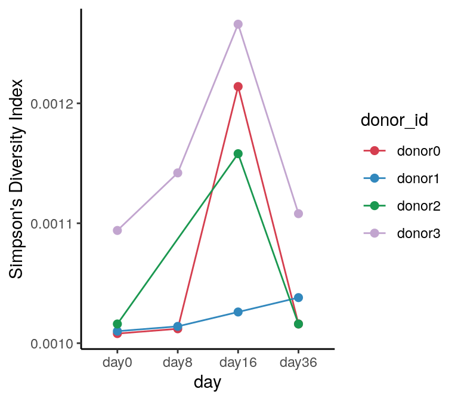

```r
ggplot(ibsm_div_day, aes(x = day, y = diversity, color = donor_id))+
  geom_line(aes(group = donor_id))+
  geom_point(size = 2)+
  theme_classic()+
  ylab("Simpson's Diversity Index")+
  scale_color_manual(values = donor_col)
```

#### Figure 4 G | Clonal overlap at day 16 across clusters. Clonal size is indicated in count in top bar, each clonal proportion across subsets is indicated.

```r
##subset to clonal frequency higher than 1
ibsm_rep <- subset(ibsm_rep, subset = clonalFrequency != 1)
```

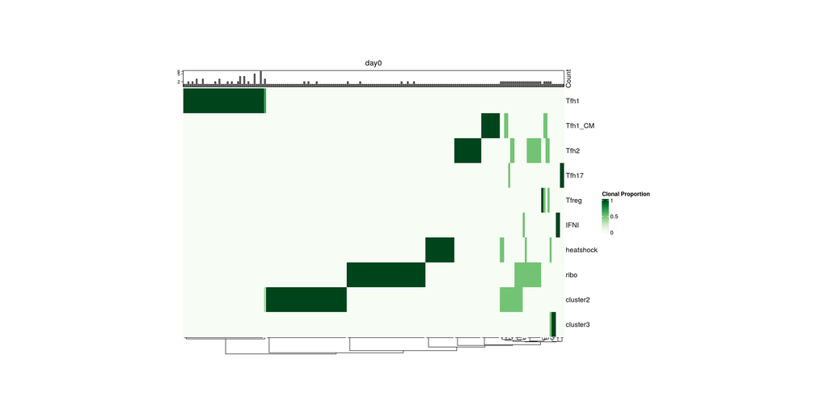

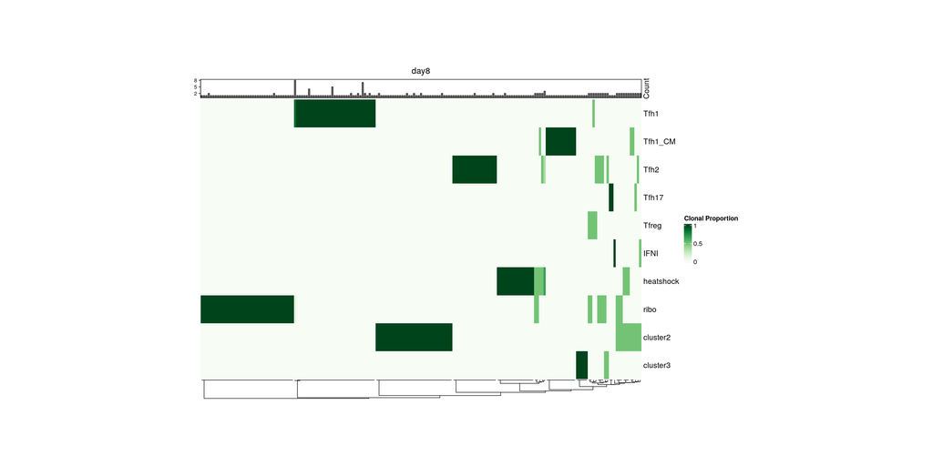

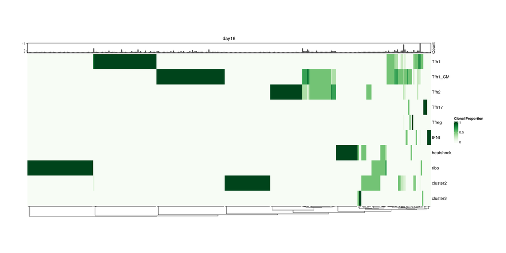

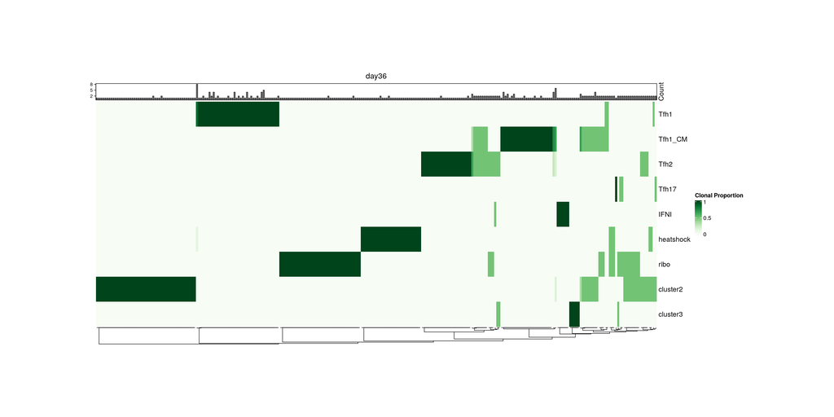

```r
for (i in unique(ibsm_rep@meta.data$day)){
  fidel <- ibsm_rep@meta.data %>%
    filter(., day == i) %>%
    select(CTaa, alternative_clusters) %>%
    tibble::remove_rownames() %>%
    group_by(CTaa, alternative_clusters) %>%
    summarise(n = n()) %>%
    ungroup() %>%
    group_by(CTaa) %>%
    mutate(total = sum(n)) %>%
    ungroup() %>%
    mutate(prop = n/total) %>%
    select(-c(n, total)) %>%
    pivot_wider(names_from = CTaa, values_from = prop) %>%
    arrange(., alternative_clusters) %>%
    column_to_rownames(., var = "alternative_clusters") %>%
    mutate_all(~replace(., is.na(.), 0)) %>%
    arrange()

  count_per_clone <- ibsm_rep@meta.data %>%
    filter(., day == i) %>%
    select(CTaa) %>%
    tibble::remove_rownames() %>%
    group_by(CTaa) %>%
    summarise(n = n())
  max_count <- max(count_per_clone$n)

  cluster_count <- ibsm_rep@meta.data %>%
    filter(., day == i) %>%
    select(CTaa, alternative_clusters) %>%
    remove_rownames() %>%
    group_by(alternative_clusters) %>%
    summarise(n = n()) %>%
    mutate(prop = n/sum(n)*100) %>%
    column_to_rownames(., var = "alternative_clusters")

  fidel <- as.matrix(fidel)

  print(Heatmap((fidel),
          column_title = paste0(i),
          name = "Clonal Proportion",
          cluster_columns = T, column_dend_side = "bottom", clustering_method_columns = "ward.D2",
          cluster_rows = F,
          show_column_names = F,
          # left_annotation = rowAnnotation(Prop = anno_barplot(
          #   cluster_count$prop, axis_param = list(direction = "reverse")),
          #                                                   annotation_name_rot = 90),
          top_annotation = HeatmapAnnotation(Count = anno_barplot(
            count_per_clone$n, axis_param = list(at = c(2, 5, max_count))),
            annotation_name_rot = 90),
          # rect_gp = gpar(col = "white", lwd = 0.5),
          width = ncol(fidel)*unit(0.05, "in"),
          height = nrow(fidel)*unit(0.6, "in"),
          col = colorRampPalette(RColorBrewer::brewer.pal(9, "Greens"))(100))
  )
          # Use continuous scale with 100 shades
  dev.set()
}
```

## Figure 5

##### Reading input

```r
upset0 <-  read.csv(file="/working_groups/boylelab/shared/ZulyPava/Tfh_diversity_finalcode/input/psbulk_sigGens_all_DayClusters_080824.csv", row.names = 1)

##Getting dataset
##Input
## Long format: gene, pval, logFC, cluster, day
## From pseudobulk analysis subset of genes with p_adj <0.005 and
## LogFC>abs(1)

upset1 <- upset0[,c(3,8,4,1,2)]
#Change colnames
colnames(upset1)[4] ="celltype"
colnames(upset1)[3] ="Log2FC"
colnames(upset1)[2] ="p_adj"

#reorder...
upset1$day <- factor(upset1$day, levels = c("day8", "day16", "day36"))
upset1$celltype <- factor(upset1$celltype, levels = c("Tfh1", "Tfh1CM", "Tfh2", "Tfh17", "Tfreg", "IFNI", "heatshock",
                                                     "ribo", "cluster2", "cluster3"))
```

#### Figure 5 A | DEGs for each cluster were calculated at day 8, 16, and 36 compared to day 0. The number of DEGs for each subset and timepoint.

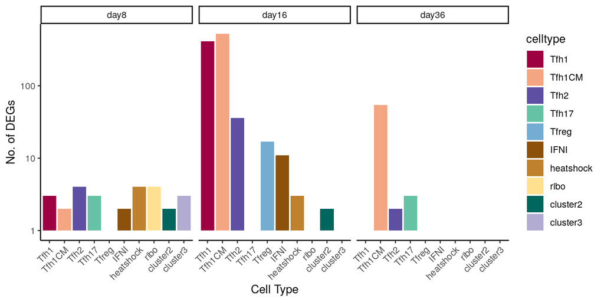

```r
Tfh_colors_list <- c("#9e0142", "#f4a582", "#5e4fa2", "#66c2a5", "#74add1",
                     "#8c510a", "#bf812d", "#fee090", "#01665e", "#b2abd2")


# Create the bar plot with custom colors
ggplot(upset1, aes(x = celltype, fill = celltype)) +
  geom_bar() +  # Counts occurrences of each celltype
  facet_wrap(~ day) +  # Facet by day
  labs(x = "Cell Type", y = "No. of DEGs") +
  theme_classic() +  # Black-and-white theme
  scale_fill_manual(values = Tfh_colors_list) +  # Apply custom colors
  theme(axis.text.x = element_text(angle = 45, hjust = 1)) +  # Rotate x-axis labels for readability
  scale_y_continuous(trans = "log10")
```

#### Figure 5 B | Venn diagram indicating the shared and unique DEGS at day 16 for Tfh1_cytotoxic, Tfh1_CCR7 and Tfh2 subsets.

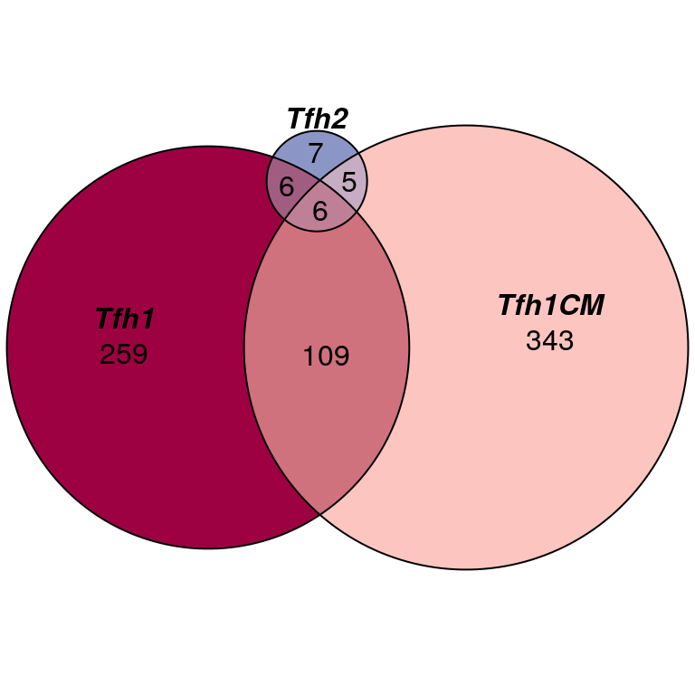

```r
# Input in the form of a named numeric vector
fit1 <- euler(c(
  "Tfh1" = 259,
  "Tfh1CM" = 343,
  "Tfh2" = 7,
  "Tfh1&Tfh1CM" = 109,
  "Tfh1&Tfh2" = 6,
  "Tfh1CM&Tfh2" = 5,
  "Tfh1&Tfh1CM&Tfh2" = 6
))

fill_colors <- c("#9e0142", "#fcc5c0", "#8c96c6")  # Replace with your desired colors

# Remove fills, vary borders, display quantities, and switch font.
plot(
  fit1,
  quantities = TRUE,
  fill = fill_colors,
  lty = 1, #solid lines for circles
  labels = list(font = 4)
)
```

```r
TfhIBSM <- readRDS("/working_groups/boylelab/shared/ZulyPava/Tfh_diversity_finalcode/input/Tfh.IBSM.2_REANNOTATION_POSTNORM_V2_200724.rds")

Tfh.16 <- subset(TfhIBSM, subset = day == "day16")

DefaultAssay(Tfh.16)
```

```
## [1] "RNA"
```

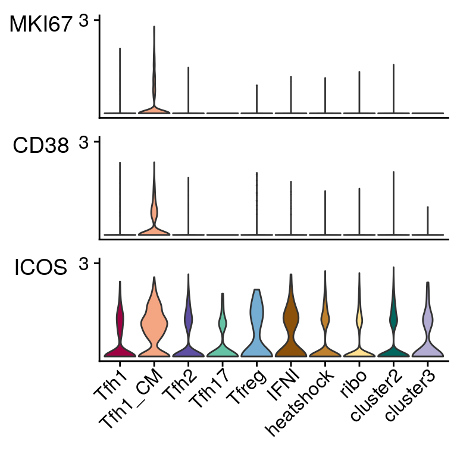

```r
log.data <- GetAssayData(Tfh.16[["RNA"]], layer = "data")
Tfh.16_b <- SetAssayData(Tfh.16,
                       layer = "data",
                       new.data = log.data,
                       assay = "RNA")
# to check if lognorm has been performed... or alternatively just run each counts/data separately, logorm will be non-integers ie 1.xxx
#Tfh.16[['RNA']]@counts@x == Tfh.16[['RNA']]@data@x

# Activation genes

Stacked_VlnPlot(Tfh.16_b, features = c("MKI67", "CD38", "ICOS"), x_lab_rotate = TRUE,
                group.by = "alternative_clusters", colors_use = Tfh_colors_list)
```

##### Getting data for Figure5D

```r
#Tfh.IBSM <- readRDS(here("input/TfhIBSM_mappedtofullREF_reannotated_230523_v2.rds"))
TfhIBSM <- readRDS("/working_groups/boylelab/shared/ZulyPava/Tfh_diversity_finalcode/input/Tfh.IBSM.2_REANNOTATION_POSTNORM_V2_200724.rds")

TfhIBSM@meta.data$alternative_clusters <- factor(TfhIBSM@meta.data$alternative_clusters,
                                                 levels = c("Tfh1", "Tfh1_CM", "Tfh2", "Tfh17",
                                                            "Tfh1.17", "Tfreg", "IFNI",
                                                            "heatshock", "ribo", "cluster2",
                                                            "cluster3"))

## first we want to get a pseudobulk count matrix..

# renaming cluster for ease.. (you can skip this if you don't need)
TfhIBSM@meta.data$alternative_clusters <- gsub("Tfh1_CM", "Tfh1CM", TfhIBSM@meta.data$alternative_clusters, fixed = TRUE)

TfhIBSM@meta.data$donor_day_cluster <- paste(TfhIBSM@meta.data$donor_day, TfhIBSM@meta.data$alternative_clusters, sep = "_")

TfhIBSM@meta.data$donor_day_cluster <- factor(TfhIBSM@meta.data$donor_day_cluster)

# now getting pseudobulk counts by the combination I want: donor_day_cluster
DefaultAssay(TfhIBSM) <- "RNA"

TfhIBSM<- NormalizeData(TfhIBSM)

# this is right... you aggregate using raw counts...
TfhIBSM.Average <- AggregateExpression(TfhIBSM, group.by = "donor_day_cluster", slot = "counts", assays = "RNA", return.seurat = T)
```

```
## Names of identity class contain underscores ('_'), replacing with dashes ('-')
##
```

```r
### tidying up metadata naming
TfhIBSM.Average@meta.data$donor_day_cluster <- as.factor(rownames(TfhIBSM.Average@meta.data))

# Split name column into firstname and last name
TfhIBSM.Average@meta.data[c("donor", "day", "seurat_clusters")] <- str_split_fixed(TfhIBSM.Average@meta.data$donor_day_cluster, "-", 3)

# Now extract the pseudobulked log-counts (NON-SCALED)

TfhIBSM.scalemat <- GetAssayData(TfhIBSM.Average, layer = "data") # data is already log-normalised..

## put in metadata
TfhIBSM.meta <- as.data.frame(TfhIBSM.Average@meta.data)
TfhIBSM.scalemat <- as.data.frame(TfhIBSM.scalemat)
TfhIBSM.scalemat <- as.data.frame(t(TfhIBSM.scalemat))

TfhIBSM.scalemat$donor_day_cluster<- rownames(TfhIBSM.scalemat)


Average.df <- merge(x = TfhIBSM.scalemat, y = TfhIBSM.meta, by = "donor_day_cluster")

# write.csv(Average.df, "TfhIBSM_Averagemat_LOGNORMALISED_donordaycluster_V2_090824.csv")

# Average.df <- read.csv("TfhIBSM_Averagemat_LOGNORMALISED_donordaycluster_V2_090824.csv", row.names = 1)
rownames(Average.df) <- Average.df$donor_day_cluster

Average.df$day <- factor(Average.df$day, levels = c("day0", "day8", "day16", "day36"))
Average.df$seurat_clusters <- factor(Average.df$seurat_clusters, levels = c("Tfh1", "Tfh1CM", "Tfh2", "Tfh17",
                                                                            "Tfreg", "IFNI",
                                                                            "heatshock", "ribo", "cluster2",
                                                                            "cluster3"))


### subset
Average.dfsub <- Average.df[Average.df$day == "day16", ]
Average.dfsub <- Average.dfsub[Average.dfsub$seurat_clusters %in% c("Tfh1", "Tfh1CM", "Tfh2"), ]


#### okay now to reorder EVERYTHING...

my_order <- c("donor0-day16-Tfh1", "donor1-day16-Tfh1", "donor2-day16-Tfh1", "donor3-day16-Tfh1",
              "donor0-day16-Tfh1CM", "donor1-day16-Tfh1CM", "donor2-day16-Tfh1CM", "donor3-day16-Tfh1CM",
              "donor0-day16-Tfh2", "donor1-day16-Tfh2", "donor2-day16-Tfh2", "donor3-day16-Tfh2")

Average.dfsub <- Average.dfsub[match(my_order, rownames(Average.dfsub)), ]

### now reoreder everything else I want as well...
Average.dfsub$seurat_clusters <- factor(Average.dfsub$seurat_clusters, levels = c("Tfh1","Tfh1CM", "Tfh2"))
Average.dfsub$donor <- factor(Average.dfsub$donor, levels = c("donor0", "donor1", "donor2", "donor3"))


### subset gene lists...

Tfh1CMgenes <- upset1%>%filter(celltype=="Tfh1CM")
Tfh1genes <- upset1%>%filter(celltype=="Tfh1")
Tfh2genes <- upset1%>%filter(celltype=="Tfh2")


# edgeR was done - D16 v D0, so logFC< 0 = up at d16, log FC >0 = down at d16, but up at day 0
Tfh1CMgenes$dir_sig[Tfh1CMgenes$p_adj<0.05 & Tfh1CMgenes$Log2FC<0] <-"up"
Tfh1CMgenes$dir_sig[Tfh1CMgenes$p_adj<0.05 & Tfh1CMgenes$Log2FC>0] <-"down"
Tfh1genes$dir_sig[Tfh1genes$p_adj<0.05 & Tfh1genes$Log2FC<0] <-"up"
Tfh1genes$dir_sig[Tfh1genes$p_adj<0.05 & Tfh1genes$Log2FC>0] <-"down"
Tfh2genes$dir_sig[Tfh2genes$p_adj<0.05 & Tfh2genes$Log2FC<0] <-"up"
Tfh2genes$dir_sig[Tfh2genes$p_adj<0.05 & Tfh2genes$Log2FC>0] <-"down"

# let's get D16up - top 50
Tfh1CMgenes <- Tfh1CMgenes[order(Tfh1CMgenes$Log2FC),]
topCM <- head(Tfh1CMgenes, n=20)
Tfh1genes <- Tfh1genes[order(Tfh1genes$Log2FC),]
top1 <- head(Tfh1genes, n=20)
Tfh2genes <- Tfh2genes[order(Tfh2genes$Log2FC),]
top2 <- head(Tfh2genes, n=20)


# Extract gene columns and merge
merged_genes <- unique(c(topCM$gene, top1$gene, top2$gene))

dfsub_16<- Average.dfsub[, colnames(Average.dfsub) %in% merged_genes]

dfsub_16 <- as.matrix(dfsub_16)
dfsub_16 = scale(dfsub_16)


col = list(Cluster = c("Tfh1" = "#b2182b", "Tfh1CM" = "#fbb4ae", "Tfh2" = "#6e016b"),
           Donor = c("donor0" = "#cb7a88", "donor1" = "#ccab7b", "donor2" = "#a3cb7a", "donor3" = "#7cbecc"))

ha <- HeatmapAnnotation(Cluster=Average.dfsub$seurat_clusters,
                        Donor=Average.dfsub$donor,
                        col = col)
```

#### Figure 5 D | Expression of top 50 unique upregulated genes for Tfh1_Cyto, Tfh1_CCR7 and Tfh2

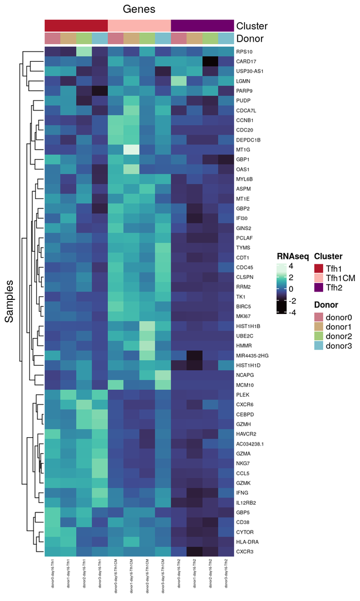

```r
Heatmap(t(dfsub_16),
        name = "RNAseq", col=mako(50),
        top_annotation = ha,
        cluster_rows = TRUE, cluster_columns = FALSE,
        column_title = "Genes", row_title = "Samples",
        row_names_gp = gpar(fontsize=6),
        column_names_gp = gpar(fontsize=4))
```